# single cell RNA-seq workflow

After running through the 10X cellranger to count and aggregate the data. Create the Seurat Object by loading the aggr file that contains the the matrix.mtx, genes.tsv (or features.tsv), and barcodes.tsv files.

Below is an example of single cell RNA-seq data obtained from [Ortmann et. al, 2020](https://www.sciencedirect.com/science/article/pii/S193459092030357X). The study has 4 replicates for each time-point but one sample from each time point (shown below) was taken to run through cellranger to generate the aggr matrix file which was used in Seurat.

| File_1 | File_2 | Treatment | Timepoint |
| --- | --- | --- | --- |
| SIGAF1_S4_L001_R1_001.fastq.gz | SIGAF1_S4_L001_R2_001.fastq.gz | 2iLif | Day 0 |
| SIGAG1_S6_L001_R1_001.fastq.gz | SIGAG1_S6_L001_R2_001.fastq.gz | N2B27 | Day 1 |
| SIGAG9_S12_L001_R1_001.fastq.gz | SIGAG9_S12_L001_R2_001.fastq.gz | N2B27 | Day 2 |

```r
library(Seurat)
```

## Preprocessing workflow

The below steps will analyze for quality, filter out low-quality cells, empty droplets and doublets then normalize.

The QC metrics are stored in the seurat object. We will add the percentage of reads that map to the mitochondrial genome to a column in the meta.data.

|  | orig.ident | nCount_RNA | nFeature_RNA | percent.mt |
| --- | --- | --- | --- | --- |
| AAACCCAGTATTCTCT-1 | mESC_diff | 1608 | 879 | 4.726368 |
| AAACGAAAGCATTTGC-1 | mESC_diff | 4379 | 1696 | 3.060059 |
| AAACGAAAGGATCACG-1 | mESC_diff | 2700 | 1287 | 2.592593 |
| AAACGAAAGTTGAAAC-1 | mESC_diff | 3935 | 1569 | 4.803050 |
| AAACGAAGTCACGTGC-1 | mESC_diff | 588 | 424 | 3.571429 |

Observe the QC metrics to filter the cells

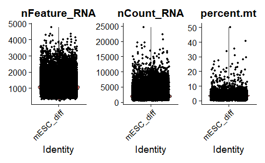

We can plot the relationship of read counts (nCount_RNA) vs the number of genes and percent of mitochondrial reads. Cells with a high percent of mitochondiral reads should be filtered out as they represent cells going through apoptosis or lysing.

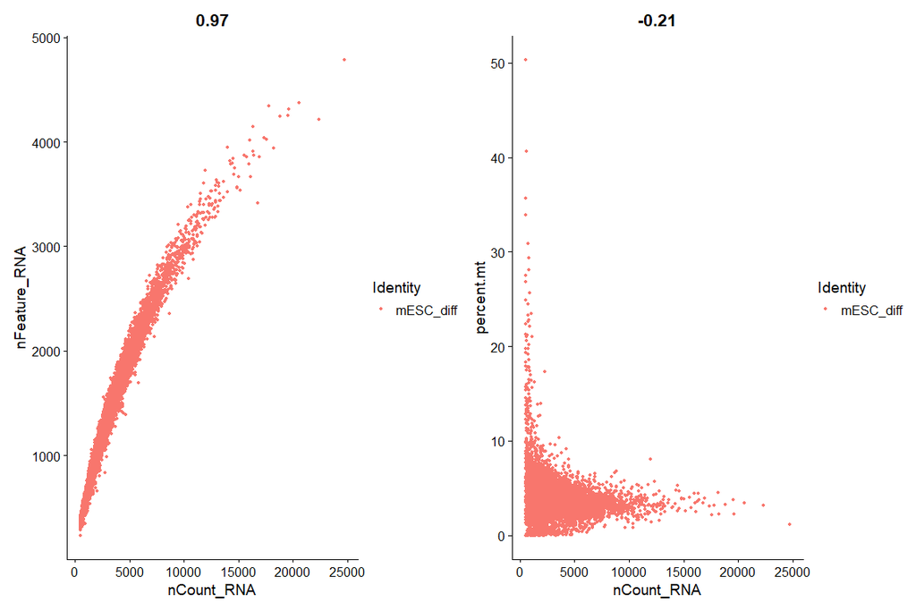

```r
# We can observe the relationship of the features and read counts
plot1 <- FeatureScatter(mesc, feature1 = "nCount_RNA", feature2 = "nFeature_RNA")
plot2 <- FeatureScatter(mesc, feature1 = "nCount_RNA", feature2 = "percent.mt")
plot1 + plot2
```

```r
# keep cells with features between 200-3500.
mesc <- subset(mesc, subset = nFeature_RNA > 200 & nFeature_RNA < 3500)
```

### Normalizing the data

The latest normalization implemented by `SCTransform()`, pools the information across genes with similar abundances and perform a regularized negative binomial regression. This preserves the biological heterogeneity.

The `SCTransform()` also can remove confounding sources of variation such as mitochondrial mapping percentage. It will also return the highly variable genes used for PCA and UMAP analysis.

```r
mesc <- SCTransform(mesc, vars.to.regress = "percent.mt")
```

## Perform linear dimensional reduction

PCA is performed on the scaled data.

```r
mesc <- RunPCA(mesc, features = VariableFeatures(object = mesc))
```

```
PC_ 1
Positive:  Gm5039, Gm8300, B020031M17Rik, Gm21761, Gm5662, Platr31, Zfp560, BC080695, Zscan4d, BC147527
       AF067061, Gm20767, Lonp2, Ccser1, Gm21818, Ftl1, Sp110, Tcstv1, Scamp1, Scd3
       Gm21319, Gm2016, Ercc4, Cwc22, Zscan4-ps2, Zscan4c, Gm13119, Arg2, Tmem132c, Tcstv3
Negative:  Ftl1-ps1, Eno1b, Malat1, Ptma, BC004004, Ldha, Meg3, mt-Co3, Apoe, Rpl26
       Rhox5, Gm10260, mt-Cytb, Utf1, Zfp42, Aldoa, Tpm3-rs7, Gm10131, Cdkn1a, Fabp5
       Snhg11, Mzt2, Gm32885, Id1, Tubb6, Gm49504, Smtnl1, Pgk1, Epcam, Upp1
PC_ 2
Positive:  Ftl1-ps1, Eno1b, Gm5039, BC004004, Gm8300, B020031M17Rik, Gm21761, mt-Co3, Rpl26, Gm5662
       Ldha, Platr31, Gm10260, AF067061, BC080695, Zfp560, Rhox5, Ptma, Zscan4d, BC147527
       Gm21818, Sp110, Gm10131, Lonp2, Gm20767, Ccser1, Apoe, mt-Cytb, Tcstv1, Tpm3-rs7
Negative:  Ftl1, Hspb1, mt-Co1, mt-Nd2, Rps18, Tmsb4x, Mylpf, Rplp0, Stmn1, Rps20
       Rpl13, Mt1, Ly6e, Tuba1b, Spp1, Gapdh, Tdgf1, Rpl21, Sept1, Rps8
       Ipp, Rps24, Phgdh, Hnrnpf, Ckb, Folr1, 1700097N02Rik, Nupr1, Selenow, Gas5
PC_ 3
Positive:  Spp1, Gabarapl2, Ckb, Tdh, Mylpf, Klf4, Klf2, Tfcp2l1, Nanog, Apoe
       Cd9, Dppa5a, Calcoco2, Gjb3, Pdgfa, Jam2, Tbx3, Zfp42, Hspb1, Tmsb10
       Npc2, Sp5, Asns, Lap3, Klf5, Cdx1, Eif2s2, Ass1, Fabp3, Ifitm1
Negative:  Ftl1, Lefty1, Mdk, Mif, Fth1, Basp1, Malat1, Meg3, Stmn1, Utf1
       Epcam, Pou3f1, Dnmt3b, Tuba1a, Calca, Gng3, Ldha, H3f3b, Fabp5, Tmsb4x
       Gadd45g, Igfbp2, Fdps, Dnmt3a, Sinhcaf, Ipp, Pclaf, Car2, Foxp1, Folr1
PC_ 4
Positive:  Rhox5, Rpl29, Rps2, Lefty1, Gm10131, Dppa5a, 1700013H16Rik, Dazl, Rpl13, Malat1
       Eno1, BC004004, Bst2, Gm10320, Krt8, Car2, Rps20, Gpx4, Eef1a1, Krt18
       Tubb6, Eif2s2, Spp1, 2810403D21Rik, H19, Pmvk, Npc2, Rpl39l, Tmsb10, Tpm1
Negative:  Eno1b, Rps3a1, Ptma, Gm49504, Smtnl1, Tdh, Rps24, Erh, Fabp5, Atp5g1
       Stmn1, Polr2f, Znrd2, H2afz, Hsp90aa1, Mrpl17, Rps12, Ifitm3, Stmn2, Mylpf
       Id1, mt-Nd2, Ncl, Dynll1, Abcc3, Rplp1, Npm1, Hexb, Hspd1, Smim40
PC_ 5
Positive:  Rpl29, Rps18, Rps3a1, Rps2, Rpl26, Bola1, Rpl21, Rpl32, Myo1f, Ube2s
       AI662270, Gm21319, Gm47283, Apoa2, Gm20767, mt-Nd3, Mkrn1, Gc, Dppa2, mt-Nd1
       Mdk, Rhox5, Nelfa, Arl6ip1, Aqp9, Ccnd2, Pou3f1, Dbi, Mthfd2, Gm49698
Negative:  Gm10260, Stmn1, Ly6e, Dppa5a, 1700097N02Rik, Ipp, Rpl13, Mt1, Ftl1, BC004004
       mt-Co3, Meg3, Cstb, Rpl18a, Rps12, Baiap2l1, Glo1, Eif2s3y, Gm21761, Mylpf
       H2afx, Rpl39l, Ckb, Fgfbp1, Lgals4, Gm8953, Gm11361, Rps24, Gm48168, Klf2
```

```r
mesc <- FindClusters(mesc, resolution = 0.5)
```

```
Modularity Optimizer version 1.3.0 by Ludo Waltman and Nees Jan van Eck

Number of nodes: 13496
Number of edges: 572828

Running Louvain algorithm...
```

```
Maximum modularity in 10 random starts: 0.9317
Number of communities: 13
Elapsed time: 1 seconds
```

## Perform non-linear dimensional reduction (UMAP/tSNE)

The best way to confirm the clustering you observe in a UMAP/tSNE is to run multiple clustering tools and observe similar clustering and gene features within those clusters.

```r
mesc <- RunUMAP(mesc, dims = 1:30, umap.method = 'umap-learn', metric = 'correlation' )
```

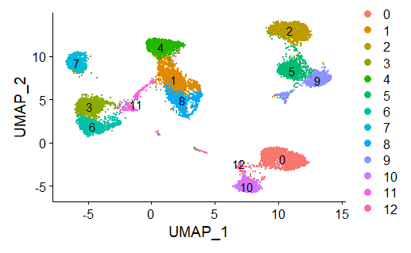

```r
DimPlot(mesc, reduction = "umap", label = TRUE)
```

You can access the corrected UMI counts from `mesc[["SCT"]]@counts`. The log-normalized counts are in `mesc[["SCT"]]@data`.

## Finding differentially expressed genes (cluster biomarkers)

We can find markers within a cluster that are different (highly variable) compared to the other clusters. I have chosen to use MAST (Model-based Analysis of Single-cell Transcriptomics) which has been shown in [Soneson & Robinson, 2018](https://www.nature.com/articles/nmeth.4612) to be one of the methods that performed well for DE in scRNA-seq.

Below is a table of differentially expressed genes in cluster 4 compared to all other cells.

|  | p_val | avg_logFC | pct.1 | pct.2 | p_val_adj |
| --- | --- | --- | --- | --- | --- |
| Spp1 | 0.000000e+00 | 0.9579230 | 0.918 | 0.375 | 0.000000e+00 |
| Rps18 | 0.000000e+00 | 0.6703686 | 1.000 | 0.988 | 0.000000e+00 |
| Mylpf | 1.640184e-275 | 0.6241286 | 0.830 | 0.323 | 2.824889e-271 |
| Ckb | 8.163407e-266 | 0.6001707 | 0.731 | 0.235 | 1.405984e-261 |
| Klf4 | 3.952525e-323 | 0.5877689 | 0.646 | 0.143 | 6.807434e-319 |
| Gabarapl2 | 2.520492e-200 | 0.5540891 | 0.888 | 0.548 | 4.341043e-196 |
| Asns | 5.614553e-221 | 0.5455304 | 0.819 | 0.460 | 9.669945e-217 |
| Cd9 | 1.777160e-217 | 0.5170976 | 0.765 | 0.352 | 3.060803e-213 |
| Hspb1 | 1.296084e-207 | 0.5106395 | 0.938 | 0.571 | 2.232246e-203 |
| Rpl29 | 1.579071e-215 | 0.4964381 | 0.986 | 0.711 | 2.719634e-211 |

[output cut: 5 more lines]

To compare only between two clusters, cluster 4 and cluster 9:

|  | p_val | avg_logFC | pct.1 | pct.2 | p_val_adj |
| --- | --- | --- | --- | --- | --- |
| Spp1 | 1.444756e-272 | 1.4169299 | 0.918 | 0.079 | 2.488303e-268 |
| Rpl29 | 4.647196e-271 | 1.2194615 | 0.986 | 0.458 | 8.003866e-267 |
| Hspb1 | 1.881708e-262 | 1.2112905 | 0.938 | 0.194 | 3.240865e-258 |
| Mylpf | 6.719708e-237 | 1.0886282 | 0.830 | 0.039 | 1.157335e-232 |
| Gabarapl2 | 4.668178e-210 | 1.0760739 | 0.888 | 0.281 | 8.040004e-206 |
| Ftl1 | 2.114495e-258 | 0.9589928 | 1.000 | 0.965 | 3.641795e-254 |
| Rps18 | 7.405029e-276 | 0.9023501 | 1.000 | 0.987 | 1.275368e-271 |
| Ckb | 8.675231e-188 | 0.8985161 | 0.731 | 0.057 | 1.494135e-183 |
| Rps15 | 4.027784e-200 | 0.7716806 | 0.993 | 0.844 | 6.937052e-196 |
| Klf4 | 5.328001e-172 | 0.7566445 | 0.646 | 0.012 | 9.176416e-168 |

[output cut: 10 more lines]

## Visualization

You can observe specific genes within the clusters. If certain cell markers are known, such as pluripotency, then you can view these genes and see how they can be found across the different clusters. This can be used to identify the clusters as certain cell types.

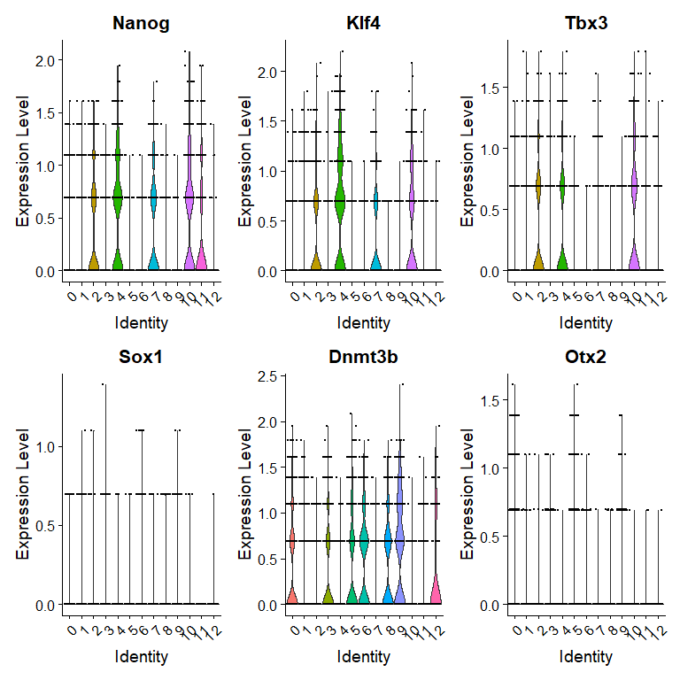

```r
VlnPlot(mesc, features = c("Nanog", "Klf4", "Tbx3", "Sox1", "Dnmt3b", "Otx2"),
    pt.size = 0.2, ncol = 3)
```

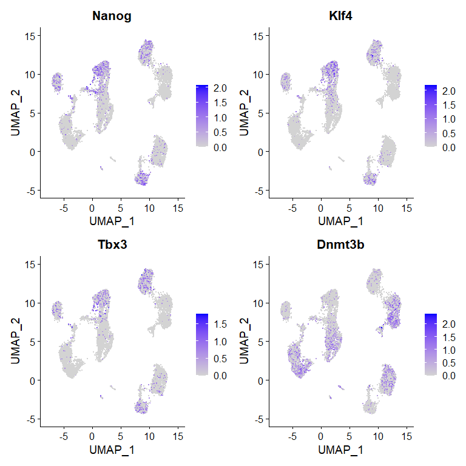

```r
# Visualize canonical marker genes on the sctransform embedding.
FeaturePlot(mesc, features = c("Nanog", "Klf4", "Tbx3", "Dnmt3b"), pt.size = 0.2,
    ncol =2)
```

Plot a heatmap of the top 20 markers for each cluster. This helps to compare the gene expression over multiple clusters at once.

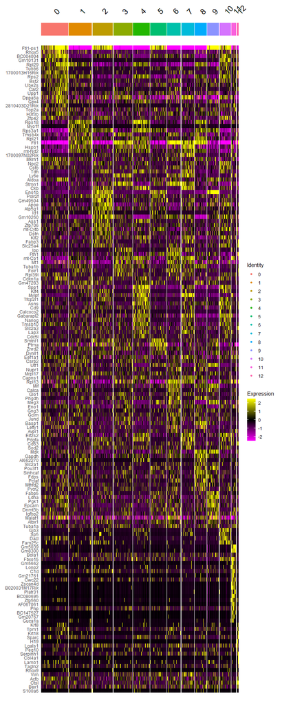

### Assigning cell type identiy to the clusters

Based on canonical markers or differentially expressed markers identified from above we can assign IDs to the clusters

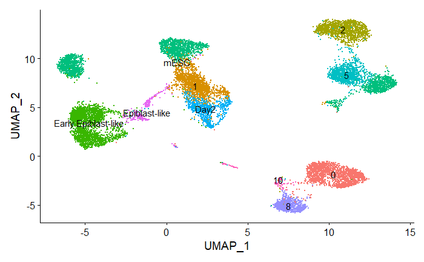